# Diagnosed hypertension among adults in Finland, Poland and Spain

Dataset 14: Quality of life among adults in Finland, Poland and Spain (COURAGE)

RSR feasibility analysis

2026-08-03

# Introduction

COURAGE in Europe is a cross-sectional survey of the general community-dwelling adult population of Finland, Poland and Spain, designed to describe healthy ageing and its social and environmental determinants; the source paper is Miret and colleagues, *PLOS ONE* (2016). The file distributed with this catalogue holds 5341 participants aged 18 to 104 (mean 57.8 years), of whom 1926 (36.1%) report a diagnosis of hypertension. Hypertension is the largest single contributor to cardiovascular mortality in Europe and is both preventable and treatable, so identifying which routinely collected characteristics mark higher diagnosed prevalence is directly useful for targeting screening.

**Aim.** Among these adults in Finland, Poland and Spain, we examined which of age, sex, country, urban or rural residence, education, BMI category, smoking status, alcohol use, physical activity and diagnosed diabetes are independently associated with having a diagnosis of hypertension, mutually adjusting for the others.

This is a *Purpose 3* analysis: several predictors are of interest and the question is which remain associated with the outcome after mutual adjustment.

# Methods

**Data source.** COURAGE in Europe, a cross-sectional multistage stratified cluster sample of the community-dwelling adult populations of Finland, Poland and Spain, fielded between 2011 and 2012. The deposited S1 file used here contains 5341 participants and 38 variables: 2632 from Poland, 2076 from Spain and 633 from Finland.

**Variables.** The outcome is `hypertension`, a binary indicator where the **event is a reported diagnosis of hypertension** (1926 events in the full file, 36.1%). This is diagnosed, not measured, hypertension - a point returned to in Limitations. Predictors are age (years), sex (reference female), country (reference Poland, the largest group), residence (reference urban), education dichotomised as high school or higher versus none, primary or secondary (reference the latter), BMI category (reference normal or underweight, the clinically unexposed group), smoking status (reference never), alcohol use in three categories (reference non-heavy drinking, the conventional reference in alcohol epidemiology because abstainers include people who stopped because they were ill), physical activity (reference high) and diagnosed diabetes (reference no).

**The predictor set is deliberately cut.** The catalogue suggests 21 predictors. Most are multi-level factors, so entering all of them costs **39 estimated parameters**, not 21: `body_pain` alone costs four, and `marital_status`, `alcohol_use`, `sleep_difficulty`, `sadness` and `distance_vision_difficulty` cost three each. With 1926 events that would be 49.4 events per parameter, which clears the conventional minimum of ten comfortably, so it should be said plainly that on this outcome the events-per-parameter rule is **not** what forces the cut. Three other considerations do. First, a 39-row odds ratio table cannot be interpreted, and the Purpose 3 question - which predictors survive mutual adjustment - is only answerable for a set small enough to reason about. Second, testing 39 coefficients at the 0.05 level means expecting about 2.0 significant results by chance alone. Third, and decisively, most of the suggested predictors have no place in a model for hypertension: they are either symptoms and disability measures that are plausibly *consequences* of cardiovascular disease, or they are downstream of the outcome itself. The set used here costs **15 parameters**, i.e. 128.4 events per parameter, and was fixed before any model was fitted.

Eleven suggested predictors are dropped. `angina` is excluded because angina is a *consequence* of long-standing hypertension, not a cause of it: adding it to this model gives an odds ratio of about 1.94, which is conditioning on a downstream variable and would bias every other coefficient. `body_pain`, `sleep_difficulty`, `sadness`, `distance_vision_difficulty`, `arthritis` and `depression_diagnosis` are excluded on the same logic - they are symptom and morbidity measures whose temporal position relative to a hypertension diagnosis is unknown, and between them they would cost 15 parameters for no gain in causal clarity. `marital_status` (3 parameters), `social_network_index`, `neighbourhood_usability` and `home_usability` are excluded because they are not established determinants of blood pressure and are more naturally read as determinants of quality of life, which is a different outcome in this catalogue. `diabetes` is retained despite sharing this ambiguity, because it is the standard comorbidity adjustment in cardiovascular models and because its interpretation here is instructive: see Limitations.

**Level collapsing.** Five categorical predictors were checked for sparse strata. `alcohol_use` has a `frequent_heavy` level with only 35 participants and 11 events, so it was pooled with `infrequent_heavy` into a single “Heavy” category (n = 285). `education` had 125 participants with no or informal education, of whom 124 live in Spain and **none** in Finland; it was collapsed to two levels, because a category that exists in only one of the three countries cannot be separated from country - and a `country`-by-`education` model on the uncollapsed variable produces outright separation (a coefficient of about -10.7 with a standard error of about 197). `marital_status` (smallest level 477), `bmi_category` (1485) and `physical_activity` (1437) were all large enough to keep as supplied, and every level of every retained predictor contains at least 81 events, so there is no zero cell and no separation.

**Statistical analysis.** `glm(family = binomial)`, justified because the outcome is binary. We fitted a univariable model for each predictor first, then a single multivariable model containing all of them. Predictors were chosen in advance on subject-matter grounds, not by significance. Coefficients are exponentiated and reported as odds ratios with 95% confidence intervals; significance threshold 0.05. Model adequacy was assessed with `performance::check_model()`, focusing on binned residuals, collinearity, influential observations and events per parameter. Models are **unweighted**: the COURAGE sampling weights, strata and clusters are not carried in this file, so no result here is a nationally representative estimate. Analysis used R version 4.6.0 (2026-04-24) with tidyverse, gtsummary and performance.

**Missing data.** There is none. All 38 columns are 100% complete in this file and 5341 of 5341 rows are complete on every variable, so the complete-case analysis uses 5341 of 5341 rows (0 dropped), leaving 1926 events. Listwise deletion costs nothing here, which means the predictor cut above rests entirely on interpretability and causal-structure grounds rather than on preserving sample size.

# Results

## Sample characteristics

**Table 1. Sample characteristics by hypertension status.**

| **Characteristic** | **N** | **No hypertension** N = 3,415<sup>1</sup> | **Hypertension** N = 1,926<sup>1</sup> |
| --- | --- | --- | --- |
| Age (years) | 5,341 | 55 (39, 65) | 67 (59, 75) |
| Sex | 5,341 |  |  |
| Female |  | 1,995 (58%) | 1,107 (57%) |
| Male |  | 1,420 (42%) | 819 (43%) |
| Country | 5,341 |  |  |
| Poland |  | 1,621 (47%) | 1,011 (52%) |
| Spain |  | 1,415 (41%) | 661 (34%) |
| Finland |  | 379 (11%) | 254 (13%) |
| Residence | 5,341 |  |  |
| Urban |  | 2,650 (78%) | 1,481 (77%) |
| Rural |  | 765 (22%) | 445 (23%) |
| Education | 5,341 |  |  |
| None, primary or secondary |  | 1,546 (45%) | 1,199 (62%) |
| High school or higher |  | 1,869 (55%) | 727 (38%) |
| BMI category | 5,341 |  |  |
| Normal or underweight |  | 1,501 (44%) | 326 (17%) |
| Overweight |  | 1,278 (37%) | 751 (39%) |
| Obese |  | 636 (19%) | 849 (44%) |
| Smoking status | 5,341 |  |  |
| Never |  | 1,599 (47%) | 931 (48%) |
| Former |  | 809 (24%) | 615 (32%) |
| Current |  | 1,007 (29%) | 380 (20%) |
| Alcohol use | 5,341 |  |  |
| Non-heavy |  | 1,796 (53%) | 781 (41%) |
| Abstainer or occasional |  | 1,415 (41%) | 1,064 (55%) |
| Heavy |  | 204 (6.0%) | 81 (4.2%) |
| Physical activity | 5,341 |  |  |
| High |  | 1,621 (47%) | 772 (40%) |
| Moderate |  | 955 (28%) | 556 (29%) |
| Low |  | 839 (25%) | 598 (31%) |
| Diagnosed diabetes | 5,341 | 189 (5.5%) | 418 (22%) |

<sup>1</sup> Median (Q1, Q3); n (%)

Participants with a hypertension diagnosis are considerably older (median 67 versus 55 years), far more often obese (44% versus 19%) and much more often diabetic (22% versus 6%). They are also less educated (38% with high school or higher versus 55%), which is one of the associations that adjustment substantially changes. Sex and urban/rural residence look similar in the two groups.

## Exploratory figure

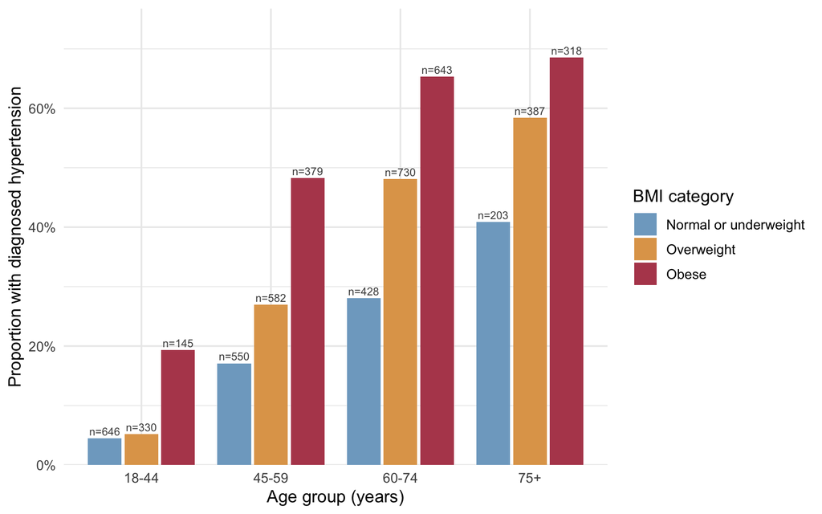

Figure 1. Proportion with diagnosed hypertension by age group and BMI category.

Diagnosed hypertension rises steeply with both age and BMI and the two compound: prevalence is around 4% among normal-weight adults under 45 and around 69% among obese adults aged 75 and over. The BMI gradient is visible within every age band, so it is not simply an artefact of older participants being heavier.

## Univariable models

| **Characteristic** | **N** | **OR** | **95% CI** | **p-value** |
| --- | --- | --- | --- | --- |
| Age (years) | 5,341 | 1.06 | 1.06, 1.07 | <0.001 |
| Sex | 5,341 |  |  |  |
| Female |  | — | — |  |
| Male |  | 1.04 | 0.93, 1.16 | 0.5 |
| Country | 5,341 |  |  |  |
| Poland |  | — | — |  |
| Spain |  | 0.75 | 0.66, 0.85 | <0.001 |
| Finland |  | 1.07 | 0.90, 1.28 | 0.4 |
| Residence | 5,341 |  |  |  |
| Urban |  | — | — |  |
| Rural |  | 1.04 | 0.91, 1.19 | 0.6 |
| Education | 5,341 |  |  |  |
| None, primary or secondary |  | — | — |  |
| High school or higher |  | 0.50 | 0.45, 0.56 | <0.001 |
| BMI category | 5,341 |  |  |  |
| Normal or underweight |  | — | — |  |
| Overweight |  | 2.71 | 2.33, 3.15 | <0.001 |
| Obese |  | 6.15 | 5.25, 7.20 | <0.001 |
| Smoking status | 5,341 |  |  |  |
| Never |  | — | — |  |
| Former |  | 1.31 | 1.14, 1.49 | <0.001 |
| Current |  | 0.65 | 0.56, 0.75 | <0.001 |
| Alcohol use | 5,341 |  |  |  |
| Non-heavy |  | — | — |  |
| Abstainer or occasional |  | 1.73 | 1.54, 1.94 | <0.001 |
| Heavy |  | 0.91 | 0.69, 1.19 | 0.5 |
| Physical activity | 5,341 |  |  |  |
| High |  | — | — |  |
| Moderate |  | 1.22 | 1.07, 1.40 | 0.004 |
| Low |  | 1.50 | 1.31, 1.71 | <0.001 |
| Diagnosed diabetes | 5,341 |  |  |  |
| No |  | — | — |  |
| Yes |  | 4.73 | 3.95, 5.69 | <0.001 |

Abbreviations: CI = Confidence Interval, OR = Odds Ratio

Obesity shows the strongest crude association: compared with normal-weight or underweight participants, obese participants have OR 6.15 (95% CI 5.25 to 7.20) (p <0.001) and overweight participants OR 2.71 (95% CI 2.33 to 3.15) (p <0.001). Diagnosed diabetes carries OR 4.73 (95% CI 3.95 to 5.69) (p <0.001). Each additional year of age multiplies the odds by OR 1.06 (95% CI 1.06 to 1.07) (p <0.001), which compounds to about 1.82-fold per decade. Education is strongly protective in crude terms: having high school education or above is associated with OR 0.50 (95% CI 0.45 to 0.56) (p <0.001), a halving of the odds. Abstinence or occasional drinking carries OR 1.73 (95% CI 1.54 to 1.94) (p <0.001) relative to non-heavy drinking, and low physical activity OR 1.50 (95% CI 1.31 to 1.71) (p <0.001). Two crude results are worth flagging as suspicious in advance: **current smoking appears protective** (OR 0.65 (95% CI 0.56 to 0.75), p <0.001) while former smoking is associated with higher odds (OR 1.31 (95% CI 1.14 to 1.49), p <0.001); and **Finland shows no crude excess** (OR 1.07 (95% CI 0.90 to 1.28), p = 0.427) although Spain does show a deficit (OR 0.75 (95% CI 0.66 to 0.85), p <0.001). Sex (OR 1.04 (95% CI 0.93 to 1.16), p = 0.503) and rural residence (OR 1.04 (95% CI 0.91 to 1.19), p = 0.555) show no crude association.

## Why adjustment is needed

**Age** is the dominant confounder and it explains both of the suspicious crude results above. Current smokers in this sample have a median age of 54 years against 62 for never smokers, so the apparently protective crude smoking odds ratio is a statement about the youth of current smokers, not about tobacco. The same mechanism drives the physical-activity association: participants in the low-activity category have a median age of 63 against 57 in the high-activity category, and inactivity is as plausibly a consequence of age-related morbidity as a cause of hypertension.

**Education** is the second confounder, and it works on the country and BMI comparisons. Participants with high school education or above have a median age of 55 against 64 for the rest - educational expansion means the less educated are simply older - and they are much less often obese (21% versus 34%). So the crude halving of the odds with education carries both an age difference and a body-mass difference. **Country** confounds in a third way: the Finnish sample is the oldest of the three (median age 66 against 57 in Poland), which is why Finland shows no crude excess despite the highest crude prevalence (40.1%). Mutual adjustment lets each odds ratio be read as a comparison between participants of the same age, sex, country, residence, education, body mass, smoking, drinking, activity level and diabetes status.

## Multivariable model

| **Characteristic** | **OR** | **95% CI** | **p-value** |
| --- | --- | --- | --- |
| Age (years) | 1.05 | 1.05, 1.06 | <0.001 |
| Sex |  |  |  |
| Female | — | — |  |
| Male | 1.07 | 0.93, 1.24 | 0.3 |
| Country |  |  |  |
| Poland | — | — |  |
| Spain | 0.53 | 0.45, 0.62 | <0.001 |
| Finland | 0.69 | 0.56, 0.85 | <0.001 |
| Residence |  |  |  |
| Urban | — | — |  |
| Rural | 0.95 | 0.80, 1.11 | 0.5 |
| Education |  |  |  |
| None, primary or secondary | — | — |  |
| High school or higher | 0.85 | 0.74, 0.98 | 0.029 |
| BMI category |  |  |  |
| Normal or underweight | — | — |  |
| Overweight | 1.98 | 1.68, 2.33 | <0.001 |
| Obese | 4.01 | 3.37, 4.78 | <0.001 |
| Smoking status |  |  |  |
| Never | — | — |  |
| Former | 1.29 | 1.09, 1.52 | 0.002 |
| Current | 1.11 | 0.93, 1.32 | 0.2 |
| Alcohol use |  |  |  |
| Non-heavy | — | — |  |
| Abstainer or occasional | 1.19 | 1.03, 1.38 | 0.019 |
| Heavy | 1.16 | 0.84, 1.58 | 0.4 |
| Physical activity |  |  |  |
| High | — | — |  |
| Moderate | 1.03 | 0.88, 1.21 | 0.7 |
| Low | 0.99 | 0.84, 1.16 | 0.9 |
| Diagnosed diabetes |  |  |  |
| No | — | — |  |
| Yes | 2.48 | 2.03, 3.03 | <0.001 |

Abbreviations: CI = Confidence Interval, OR = Odds Ratio

**Model fit: multivariable logistic model for diagnosed hypertension**

| Statistic | Value |
| --- | --- |
| Complete-case N | 5341 |
| Events (hypertension = 1) | 1926 |
| Parameters (excl. intercept) | 15 |
| Events per parameter | 128.4 |
| AIC (null model) | 6985.5 |
| AIC (full model) | 5613.0 |
| Tjur's R-squared | 0.239 |

The model has 1926 events for 15 estimated parameters, i.e. **128.4 events per parameter**, an order of magnitude above the conventional minimum of ten, so over-fitting is not a concern here. AIC falls from 6985.5 for the intercept-only model to 5613.0, a drop of 1372.6, and Tjur’s R-squared is 0.239.

Among participants of the same age, sex, country, residence, education, smoking, drinking, activity level and diabetes status, obesity is associated with OR 4.01 (95% CI 3.37 to 4.78) (p <0.001) and being overweight with OR 1.98 (95% CI 1.68 to 2.33) (p <0.001). Diagnosed diabetes carries OR 2.48 (95% CI 2.03 to 3.03) (p <0.001). Each additional year of age multiplies the odds by OR 1.05 (95% CI 1.05 to 1.06) (p <0.001), about 1.67-fold per decade. Holding everything else constant, both non-Polish countries now show lower odds than Poland: OR 0.53 (95% CI 0.45 to 0.62) for Spain (p <0.001) and OR 0.69 (95% CI 0.56 to 0.85) for Finland (p <0.001). Former smoking remains associated with OR 1.29 (95% CI 1.09 to 1.52) (p = 0.002) while current smoking is now null (OR 1.11 (95% CI 0.93 to 1.32), p = 0.239). Education retains a small independent association (OR 0.85 (95% CI 0.74 to 0.98), p = 0.029), as does abstinence or occasional drinking (OR 1.19 (95% CI 1.03 to 1.38), p = 0.019). Sex (OR 1.07 (95% CI 0.93 to 1.24)), rural residence (OR 0.95 (95% CI 0.80 to 1.11)), heavy drinking (OR 1.16 (95% CI 0.84 to 1.58)) and both physical-activity contrasts (OR 0.99 (95% CI 0.84 to 1.16) for low activity) are not independently associated. These are associations among the participants observed, not effects of intervening.

**Statistical against practical significance.** With 5341 observations and 1926 events, this model detects associations that are too small to act on. The education contrast is the clearest case: it is significant (OR 0.85 (95% CI 0.74 to 0.98), p = 0.029) but a 15% relative reduction in the odds of a diagnosis, with a confidence interval whose upper limit reaches 0.98, is not a finding on which a screening programme would be built. The same applies to abstinence (OR 1.19 (95% CI 1.03 to 1.38), p = 0.019). Compare those with obesity (OR 4.01 (95% CI 3.37 to 4.78)), which quadruples the odds, or age, which multiplies them roughly 1.7-fold per decade. A p-value below 0.05 at this sample size answers “is it distinguishable from zero”, not “is it big enough to matter”, and only the second question is useful.

## Unadjusted versus adjusted

**Table 2. Unadjusted and adjusted odds ratios.**

| **Characteristic** | **Unadjusted** **N** | **Unadjusted** **OR** | **Unadjusted** **95% CI** | **Unadjusted** **p-value** | **Adjusted** **OR** | **Adjusted** **95% CI** | **Adjusted** **p-value** |
| --- | --- | --- | --- | --- | --- | --- | --- |
| Age (years) | 5,341 | 1.06 | 1.06, 1.07 | <0.001 | 1.05 | 1.05, 1.06 | <0.001 |
| Sex | 5,341 |  |  |  |  |  |  |
| Female |  | — | — |  | — | — |  |
| Male |  | 1.04 | 0.93, 1.16 | 0.5 | 1.07 | 0.93, 1.24 | 0.3 |
| Country | 5,341 |  |  |  |  |  |  |
| Poland |  | — | — |  | — | — |  |
| Spain |  | 0.75 | 0.66, 0.85 | <0.001 | 0.53 | 0.45, 0.62 | <0.001 |
| Finland |  | 1.07 | 0.90, 1.28 | 0.4 | 0.69 | 0.56, 0.85 | <0.001 |
| Residence | 5,341 |  |  |  |  |  |  |
| Urban |  | — | — |  | — | — |  |
| Rural |  | 1.04 | 0.91, 1.19 | 0.6 | 0.95 | 0.80, 1.11 | 0.5 |
| Education | 5,341 |  |  |  |  |  |  |
| None, primary or secondary |  | — | — |  | — | — |  |
| High school or higher |  | 0.50 | 0.45, 0.56 | <0.001 | 0.85 | 0.74, 0.98 | 0.029 |
| BMI category | 5,341 |  |  |  |  |  |  |
| Normal or underweight |  | — | — |  | — | — |  |
| Overweight |  | 2.71 | 2.33, 3.15 | <0.001 | 1.98 | 1.68, 2.33 | <0.001 |
| Obese |  | 6.15 | 5.25, 7.20 | <0.001 | 4.01 | 3.37, 4.78 | <0.001 |
| Smoking status | 5,341 |  |  |  |  |  |  |
| Never |  | — | — |  | — | — |  |
| Former |  | 1.31 | 1.14, 1.49 | <0.001 | 1.29 | 1.09, 1.52 | 0.002 |
| Current |  | 0.65 | 0.56, 0.75 | <0.001 | 1.11 | 0.93, 1.32 | 0.2 |
| Alcohol use | 5,341 |  |  |  |  |  |  |
| Non-heavy |  | — | — |  | — | — |  |
| Abstainer or occasional |  | 1.73 | 1.54, 1.94 | <0.001 | 1.19 | 1.03, 1.38 | 0.019 |
| Heavy |  | 0.91 | 0.69, 1.19 | 0.5 | 1.16 | 0.84, 1.58 | 0.4 |
| Physical activity | 5,341 |  |  |  |  |  |  |
| High |  | — | — |  | — | — |  |
| Moderate |  | 1.22 | 1.07, 1.40 | 0.004 | 1.03 | 0.88, 1.21 | 0.7 |
| Low |  | 1.50 | 1.31, 1.71 | <0.001 | 0.99 | 0.84, 1.16 | 0.9 |
| Diagnosed diabetes | 5,341 |  |  |  |  |  |  |
| No |  | — | — |  | — | — |  |
| Yes |  | 4.73 | 3.95, 5.69 | <0.001 | 2.48 | 2.03, 3.03 | <0.001 |

Abbreviations: CI = Confidence Interval, OR = Odds Ratio

Two estimates move *away* from the null. **Finland** goes from OR 1.07 (95% CI 0.90 to 1.28) (p = 0.427, no association) to OR 0.69 (95% CI 0.56 to 0.85) (p <0.001, clearly protective) - a change of significance status caused by the Finnish sample being the oldest of the three, which masked a genuinely lower age-specific prevalence. **Spain** moves the same way, from OR 0.75 (95% CI 0.66 to 0.85) to OR 0.53 (95% CI 0.45 to 0.62). By contrast **age itself barely moves**, from OR 1.06 (95% CI 1.06 to 1.07) to OR 1.05 (95% CI 1.05 to 1.06), and so does **former smoking**, from OR 1.31 (95% CI 1.14 to 1.49) to OR 1.29 (95% CI 1.09 to 1.52) - neither is explained by the other measured characteristics, which is what you would expect of age and of a cumulative exposure that people typically quit *because* of a diagnosis.

## Diagnostics

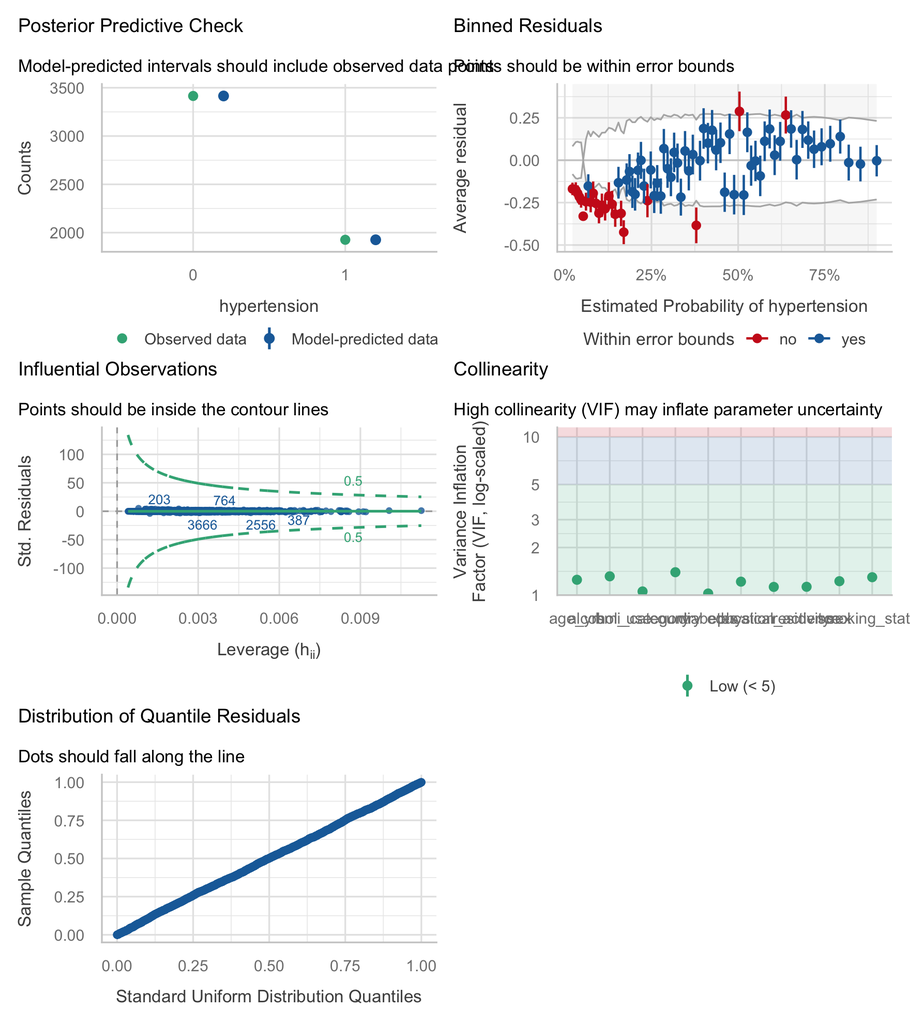

```
## Warning: Probably bad model fit. Only about 70% of the residuals are inside the error bounds.
```

| Term | VIF | VIF_CI_low | VIF_CI_high | SE_factor | Tolerance | Tolerance_CI_low | Tolerance_CI_high |
| --- | --- | --- | --- | --- | --- | --- | --- |
| age_yrs | 1.250857 | 1.213768 | 1.294380 | 1.118417 | 0.7994519 | 0.7725705 | 0.8238804 |
| sex | 1.225294 | 1.189678 | 1.267598 | 1.106930 | 0.8161305 | 0.7888937 | 0.8405633 |
| country | 1.396352 | 1.351223 | 1.447279 | 1.087048 | 0.7161520 | 0.6909518 | 0.7400704 |
| residence | 1.129426 | 1.099800 | 1.167848 | 1.062745 | 0.8854053 | 0.8562760 | 0.9092564 |
| education | 1.217091 | 1.181954 | 1.259013 | 1.103218 | 0.8216312 | 0.7942732 | 0.8460563 |
| bmi_category | 1.055569 | 1.032565 | 1.094825 | 1.013612 | 0.9473560 | 0.9133883 | 0.9684621 |
| smoking_status | 1.298563 | 1.258790 | 1.344450 | 1.067495 | 0.7700817 | 0.7437986 | 0.7944137 |
| alcohol_use | 1.315407 | 1.274700 | 1.362147 | 1.070940 | 0.7602209 | 0.7341352 | 0.7844985 |
| physical_activity | 1.127500 | 1.098008 | 1.165866 | 1.030455 | 0.8869179 | 0.8577313 | 0.9107400 |
| diabetes | 1.024572 | 1.007850 | 1.076916 | 1.012212 | 0.9760170 | 0.9285778 | 0.9922110 |

**Table 3. Separation, influence and collinearity checks.**

| Check | Value |
| --- | --- |
| Largest \|coefficient\| (log-odds) | 1.39 |
| Largest standard error | 0.202 |
| Largest VIF | 1.40 |
| Largest Cook's distance | 0.0024 |
| Largest leverage | 0.012 |
| Smallest event count in any predictor level | 81 |

The binned-residual check is the one that matters for a logistic model and it is **not reassuring**: only about 70% of binned residuals fall inside the error bounds against a target of 95% or more, and `performance` prints a “probably bad model fit” warning. With 5341 observations the bins are large enough that this is unlikely to be noise, and the most plausible explanation is that the linear-in-log-odds assumption for age is imperfect - diagnosed hypertension prevalence plateaus in the oldest participants rather than continuing to rise on the log-odds scale. Collinearity is not a problem: the largest VIF is 1.40 for country, far below the conventional threshold of 5, so country, education and residence are not competing badly despite their structural overlap. Influence is negligible: the largest Cook’s distance is 0.0024 and the largest leverage 0.012, so no participant drives the fit. There is **no separation**: every coefficient is finite, the largest standard error is 0.202, and every level of every categorical predictor contains events (Table 3). Homogeneity of variance and normality of residuals do not apply to a logistic model and are not interpreted; the corresponding panels of `check_model()` should be ignored here.

# Discussion

Among these 5341 adults in Finland, Poland and Spain, obesity, age and diagnosed diabetes are the characteristics most strongly and independently associated with having a hypertension diagnosis: obesity roughly 4.0-fold, diabetes about 2.5-fold, and age about 1.7-fold per decade, each holding the others constant. The crude protective association with current smoking and the crude harmful association with inactivity both disappear once age is held constant, and the education gradient shrinks to something statistically detectable but practically small. Country remains a substantial independent contrast: at the same age and body mass, Spanish and Finnish participants have roughly 47% and 31% lower odds of a diagnosis than Polish participants. Practically, this supports age and BMI as the primary axes for opportunistic blood-pressure screening in these populations.

**The outcome is a *diagnosis*, and that is the central interpretive problem.** Undiagnosed hypertension is misclassified as absent, and being diagnosed requires having had your blood pressure measured, which requires contact with a health system. That contact is not distributed at random: it differs by country, by education and by whether you already have another condition that brings you into a clinic. This is **differential misclassification**, and it works in a direction that can manufacture or destroy associations. The `diabetes` odds ratio of 2.48 is the clearest example - some of it is real shared aetiology through adiposity, but some of it is simply that people with diagnosed diabetes attend clinics where blood pressure is measured routinely, so their hypertension is more likely to have been *found*. The same argument applies to the education and country contrasts: the apparently lower odds in Spain and Finland could reflect genuinely lower prevalence, or different diagnostic thresholds and screening intensity, and this dataset cannot separate the two. A student reading these coefficients as prevalence differences is over-reading them.

**Limitations.** The models are **unweighted**: the COURAGE sampling weights, strata and clusters are not carried in this file, so the sample must not be described as representative of any national population, and the standard errors ignore clustering within primary sampling units, which will make them too narrow. The outcome is self-reported *diagnosed* hypertension rather than measured blood pressure, with the differential misclassification by healthcare access described above; no measured systolic or diastolic pressure is available in this file to check it. The design is cross-sectional, so reverse causation is plausible for several predictors: people diagnosed with hypertension are advised to lose weight, stop smoking and exercise, which would attenuate the BMI and activity associations and could invert the smoking one. The deposited file differs from the published paper: it holds 5341 rows with mean age 57.8 years, whereas the source paper reports 5,639 participants with mean age 46.3 years, so results here should not be compared with the published analysis. The binned-residual check fails, indicating that the model is miscalibrated in parts of the predicted-probability range and most likely that age is not linear in the log-odds. There is evidence of effect modification the additive model ignores: a country-by-education interaction improves the fit (likelihood-ratio p = 0.023), so the education gradient is not the same in all three countries; country-by-age and country-by-BMI interactions do not (p = 0.612 and p = 0.643). Eleven suggested predictors were excluded a priori, so residual confounding is certain - family history and salt intake, the two dominant determinants of blood pressure, are not measured at all. The `education` variable was collapsed to two levels, so any effect confined to the 125 participants with no formal education is invisible; that group has a crude hypertension prevalence of 61% and is almost entirely Spanish. With 5341 observations, small and practically uninteresting differences reach significance. All estimates are associations, not causal effects.

**Future work.** Refit with the COURAGE survey design (weights, strata and clusters) and with the measured blood-pressure readings from the full COURAGE files, which would replace diagnosed hypertension with measured hypertension and remove the dominant misclassification problem.

# Feasibility notes

*NOT part of a student report.*

- **USABLE. The best-powered of the three outcomes in this dataset.** 1926 events in 5341 complete rows, no missing data anywhere in the file, 128.4 events per parameter at 15 parameters, Tjur’s R-squared 0.239, no separation, no influential points (max Cook’s 0.0024), max VIF 1.40.
- **MAJOR: 21 suggested predictors cost 39 parameters, not 21.** Most are multi-level factors. Because there are 1926 events, even the full 21-predictor model runs at 49.4 events per parameter and produces **no warning of any kind** - which is precisely the trap. A student who fits everything gets an unreadable 39-row table in which about 2.0 coefficients are significant by chance, and no diagnostic will tell them anything is wrong. The brief must instruct students to count parameters (k levels cost k-1) and cut a priori.
- **MAJOR: the outcome is *diagnosed* hypertension.** Detection depends on healthcare contact, which differs by country and by education - exactly two of the predictors. This is differential misclassification and it is not recoverable from this file (no measured blood pressure is shipped). The `diabetes` odds ratio of 2.48 is partly a healthcare-contact artefact.
- **MAJOR: binned residuals fail** (about 70% inside bounds against a 95% target, with a “probably bad model fit” warning). Unlike small-sample cases this is not a bin-size artefact, because n is 5341 and the bins are large. A student following the diagnostics honestly must report a failed check; the likely cause is non-linear age.
- **MAJOR: the file does not match the paper.** 5341 rows, mean age 57.8, median 60, range 18-104; the paper reports 5,639 participants with mean age 46.3. Verified directly from the CSV. An 11.5-year gap in mean age is far too large to be a subsetting or rounding artefact and suggests the deposited S1 file is a different, older subsample. The dataset page should carry an explicit caution and students must not be asked to reproduce published numbers.
- **MAJOR trap: `angina` must not be a predictor here.** Angina is a consequence of long-standing hypertension. Added to this model it returns an odds ratio of about 1.94 and biases every other coefficient by conditioning on a downstream variable. A student building a “cardiovascular risk factor” model will reach for it.
- **MINOR: `alcohol_use` has a `frequent_heavy` level of only 35 participants** with 11 hypertension events. Uncollapsed it is estimable but the contrast is very imprecise, and a `country * alcohol_use` interaction spends six parameters on cells of 9 to 15 people (standard errors up to about 1.0 on the log-odds scale). For the depression outcome the same level *does* separate. Pooled with `infrequent_heavy` here.
- **MINOR but structural: `education == "none_or_informal"` is a Spain-only category.** 124 of its 125 members are Spanish and **zero** are Finnish, so `country * education` produces textbook separation - a coefficient of about -10.7 with a standard error of about 197, alongside a “fitted probabilities numerically 0 or 1” warning. This is the most likely way a student wrecks this outcome. Collapsed to two levels here.
- **MINOR: crude current-smoking OR is protective** (OR 0.65 (95% CI 0.56 to 0.75), p <0.001) and becomes null on adjustment. Good teaching material, but a weak student will report “smoking protects against hypertension” from the univariable table.
- **MINOR: unmodelled effect modification by country.** country-by-education likelihood-ratio p = 0.023; country-by-age and country-by-BMI are not significant. Worth a sentence, not a model change.
- **Unweighted survey analysis.** Must be stated in Methods and Limitations.